# Check 1: Cohort survival

Conducting the analysis with stateELP

Guide home | Previous: Prep 3: Program implementation | Next: Check 2: On-time vs. prolonged exiters

**Simulated data**

Every output on this page comes from the package’s simulated data. It shows what this step produces and how to read it. It says nothing about any real state: every gap, ratio and rate here comes from how the data were generated.

```r
library(stateELP)
```

## What this step answers

How long do English learners (ELs) stay in EL status? To **exit** means to be reclassified from current EL to former EL. Check 1 follows one group of students who entered EL status together and asks two questions:

1. **When do students exit?** How many years does it typically take, what share exits within the state’s timelines, and what share is still classified many grades later?
2. **Is anything besides English proficiency deciding who exits?** Once you know a student’s English language proficiency (ELP) at entry, does last year’s content-test score still predict whether they exit this year? If it does, the exit process may be favoring academically stronger students, which the package calls *skimming*.

Later stages refer to two named models. **Model 1** describes exit timing with no academic data. **Model 2** adds prior-year achievement to test for skimming.

## Sample

**One entry cohort.** A cohort is the students who first appear as current ELs in the same grade (kindergarten by default) in the same year, followed forward through every later year in the data.

Candidate cohorts come from the data’s year range and the spec’s maximum timeline, never from typed-in years. An entry year qualifies only if the data cover that year plus the maximum timeline’s worth of years after it: for a six-year timeline, seven years of data starting with the entry year. The extra year is needed because an exit at the end of one year is only seen in the next year’s data. Students already in EL status when the data begin are excluded, because their time in status cannot be measured.

Check 1 analyzes **one** cohort: the candidate with the longest follow-up that clears the **minimum cell size**, the smallest count the spec allows in a reported cell (`policy$suppression$min_cell`). Follow-up shrinks with each later entry year, so this is always the earliest candidate that clears it: the one with the least of its path cut off by the end of the data.

Students who leave the data before exiting, or are still classified when the data end, are **censored**: what happened to them afterward is unknown.

This is not the statewide population of Prep 2 or the grade-by-grade cross-sections of Checks 3 and 4, and it is not the state’s overall exit rate. `run_check1()` writes the sample statement into `res$meta$sample`; the one for the simulated data is printed under Run it.

## Status in the package

**Built.** Every result slot the stage’s instruction file names is filled, the stage report renders to Word and HTML, and its tests have no skipped placeholders. Three things are deliberately not built, and the report says so:

- **Later start grades.** `run_check1()` takes a `start_grade` argument, but the stage has been built and tested on kindergarten entrants only.
- **A per-grade selection strength.** The weighting index uses one Model 2 ratio for the whole cohort.
- **Any use of the weighting index.** It is experimental, and nothing in the package consumes it.

## Before you start

You need a spec and a data bundle, covered on the setup page.

**From the spec**, Check 1 reads:

- `policy$timelines$max_years_to_exit`, the maximum timeline. It decides which entry years qualify.
- `policy$timelines$essa_timeline_years` and `on_time_rule`, the timeline the state set under the Every Student Succeeds Act (ESSA). Together they set the “on time” row of the timeline table.
- `policy$timelines$initial_elp_source`, which must be `"first_annual"` or absent. Any other value stops the stage with an error.
- `elp$headline` and `elp$bands`: the ELP component the analyses use (the Overall Composite in the simulated spec) and its bands.
- `policy$suppression$min_cell`, the minimum cell size.

**From the data:**

- **Required** (roster): `STUDENT_ID`, `YEAR`, `GRADE`, `EL_STATUS`. If one is missing, the stage stops and names it.
- **Optional** (roster): `LEFT_TRUNCATED`. Without it, students first seen as current ELs in the data’s first year are treated as already in status and excluded.
- **Optional** (base table): `SCALE_SCORE` and `ACHIEVEMENT_LEVEL` rows for the ELP component. These drive the band split, the entry-score model and Model 2.
- **Optional** (academic table): content scores by `SUBJECT`, for Model 2.

The package derives `YEAR_IN_STATUS`, `COHORT_LABEL`, exit and censoring dates and the starting band itself; delivered columns with those names are ignored. A slot that cannot be computed is `NULL`, with a note in `res$meta`:

| Missing | Effect |
| --- | --- |
| No entry year has enough follow-up, or every candidate is below `min_cell` | Every analysis slot is `NULL`; `res$meta$note` explains |
| No annual score on the ELP component anywhere in the delivery | `$exit_curve_by_initial_band` is `NULL`; `res$meta$band_note` explains |
| The ELP component is a level only, with no scale score | `$model1_baseline` and `$model2` are `NULL`; `res$meta$model1_note` explains. Everything else still runs |
| No academic table | `$model2` is `NULL` and the selection-strength value is `NA`; `res$meta$model2_note` explains |
| The cohort has no observed exits | The fitted models are `NULL`, with a note |
| The spec does not declare Type 3 | `$type3_covariate` is `NULL` |

## Run it

Load the spec, build the bundle once, and run the stage.

```r
spec <- read_el_spec("00_SIM_EL_Spec")

bundle <- as_el_data(el_long_sim,
                     roster   = el_roster_sim,
                     academic = academic_long_sim,
                     spec     = spec)

t0  <- Sys.time()
res <- run_check1(bundle, spec)          # start_grade = "K" by default
t_run <- as.numeric(difftime(Sys.time(), t0, units = "secs"))

names(res)
```

```
 [1] "cohorts"                    "life_table"
 [3] "exit_curve"                 "exit_curve_by_initial_band"
 [5] "survival_est"               "years_to_50"
 [7] "at_max_timeline"            "model1"
 [9] "model1_baseline"            "model2"
[11] "retention_share"            "selection_strength"
[13] "grade_weights"              "type3_covariate"
[15] "meta"
```

Read the sample statement first. It names the cohort, its size and its window:

```r
res$meta$sample
```

```
[1] "The K-2015 entry cohort: 2,373 students who entered EL status in kindergarten in 2015, followed through 2025 (11 years). The most complete of the five usable K cohorts — the longest follow-up."
```

On the simulated data, `run_check1()` took about 23 seconds. On your own data, swap in your spec and tables:

```r
spec   <- read_el_spec("specs/XX_EL_Spec.R")
bundle <- as_el_data(my_base, roster = my_roster, academic = my_academic,
                     spec = spec)
res    <- run_check1(bundle, spec)
```

`run_check1()` only assembles. Each slot comes from an exported function you can call on its own:

```r
co  <- compute_cohorts(bundle, spec)
sel <- co$COHORT_LABEL[co$SELECTED]

compute_life_table(bundle, spec, cohort = sel)
compute_exit_curve(bundle, spec, cohort = sel)                      # overall
compute_exit_curve(bundle, spec, cohort = sel, by = "INITIAL_ELP")  # by band
est <- compute_survival_est(bundle, spec, cohort = sel)
compute_years_to_50(est)
compute_at_max_timeline(bundle, spec, cohort = sel)
compute_model1(bundle, spec, cohort = sel)                       # unconditional
compute_model1(bundle, spec, cohort = sel, baseline_elp = TRUE)  # entry score
compute_model2(bundle, spec, cohort = sel)                       # + prior year
```

## What you get

`res` is a named list of aggregate tables and model summaries, plus `$meta`. No slot holds one row per student. The sections below follow the stage report.

### The data fields used

The report opens with the fields the run used and what each did, generated from the same declaration the code validates its inputs against.

```r
ft_check1_data_fields(res)
```

| Field | Used for |
| --- | --- |
| STUDENT_ID | Follows one student across years, and counts the cohort once per student. |
| YEAR | Places each row in the panel: sets the follow-up window, and each student's year in status. |
| GRADE | Fixes the entry grade that defines the cohort, and labels each life-table row. |
| EL_STATUS | The current / former transitions that date entry, exit and censoring. |
| LEFT_TRUNCATED | Excludes students already in EL status when the panel opened, whose time in status cannot be measured. (optional) |
| COMPONENT | Picks out the Overall Composite: the counts and bands on this page are built on it. (optional) |
| ACHIEVEMENT_LEVEL | The Overall Composite level at the student's first year in status, banded into the initial ELP band. (optional) |
| ELP_FORM | Keeps the annual assessment only: alternate-form levels are on a different scale and never enter a band. (optional) |
| SCALE_SCORE (base) | The Overall Composite scale score at the student's FIRST year in status: where they started, which the fitted models use as a covariate. The current year's score is deliberately not used -- the exit r… |
| SUBJECT | Selects the content subject whose prior-year score enters Model 2. (optional) |
| SCALE_SCORE (academic) | The prior-year content score: the covariate that tests for skimming, lagged so it cannot be an effect of exiting. (optional) |

### The candidate cohorts: `$cohorts`

```r
res$cohorts
```

```
# A tibble: 5 × 6
  COHORT_LABEL COHORT_START_YEAR N_ENTRY FOLLOWUP_YEARS SELECTED SUPPRESSED
  <chr>                    <int>   <int>          <int> <lgl>    <lgl>
1 K-2015                    2015    2373             11 TRUE     FALSE
2 K-2016                    2016    2360             10 FALSE    FALSE
3 K-2017                    2017    2411              9 FALSE    FALSE
4 K-2018                    2018    2403              8 FALSE    FALSE
5 K-2019                    2019    2374              7 FALSE    FALSE
```

`COHORT_LABEL` is the entry grade and year, `N_ENTRY` the number of students, and `FOLLOWUP_YEARS` the years from entry through the end of the data. `SELECTED` marks the analyzed cohort. A candidate below the minimum cell size has `SUPPRESSED = TRUE`, a blank count, and can never be selected. The table carries no outcomes. Check 2 calls `compute_cohorts()` itself, so it analyzes the same cohort.

### The life table: `$life_table`

The life table is the core of Model 1, with one row per **year in status**, counted from a student’s first year as a current EL.

```r
ft_check1_life_table(res)
```

| Grade (year in status) | A Enrolled at year's beginning | B Exited at year's end | C Disappeared at year's end | D Annual exit rate (B/A) | E Annual censor rate (C/A) | F Cumulative exit rate (ΣB/A₁) |
| --- | --- | --- | --- | --- | --- | --- |
| K (Y1) | 2,373 | 0 | 0 | 0.00 | 0.00 | 0.00 |
| G1 (Y2) | 2,373 | 37 | 0 | 0.02 | 0.00 | 0.02 |
| G2 (Y3) | 2,336 | 371 | 0 | 0.16 | 0.00 | 0.17 |
| G3 (Y4) | 1,965 | 570 | 0 | 0.29 | 0.00 | 0.41 |
| G4 (Y5) | 1,395 | 440 | 0 | 0.32 | 0.00 | 0.60 |
| G5 (Y6) | 955 | 234 | 0 | 0.25 | 0.00 | 0.70 |
| G6 (Y7) | 721 | 128 | 0 | 0.18 | 0.00 | 0.75 |
| G7 (Y8) | 593 | 94 | 0 | 0.16 | 0.00 | 0.79 |
| G8 (Y9) | 499 | 36 | 0 | 0.07 | 0.00 | 0.80 |
| G9 (Y10) | 463 | 31 | 0 | 0.07 | 0.00 | 0.82 |
| G10 (Y11) | 432 | — | 432 | 0.00 | 1.00 | — |

- **A, enrolled at year’s beginning:** students still classified and still in the data. They are “at risk” of exiting.
- **B, exited at year’s end:** students who appear as former ELs in the *next* year’s data. An exit is dated to the first year a student appears as former, and that year counts as a year in status. Row 5’s exiters have an exit year of 6.
- **C, disappeared at year’s end:** students last seen this year with no exit. They are **censored**: we stop observing them, which is not evidence that they stayed in status.
- **D = B / A:** the annual exit rate among students at risk, also called the discrete-time **hazard**.
- **E = C / A:** the annual censoring rate.
- **F = cumulative B / the starting cohort:** the share of the original cohort observed to have exited. It is a **lower bound**, because every censored student holds it down.

Each row’s A is the previous row’s A minus its B and C:

```r
with(res$life_table, all(head(A - B - C, -1) == A[-1], na.rm = TRUE))
```

```
[1] TRUE
```

The last row is the edge of the data. No later year exists in which to observe an exit, so B is empty and everyone still at risk is counted in C.

### The exit curves: `$exit_curve` and `$exit_curve_by_initial_band`

The exit curve draws column F.

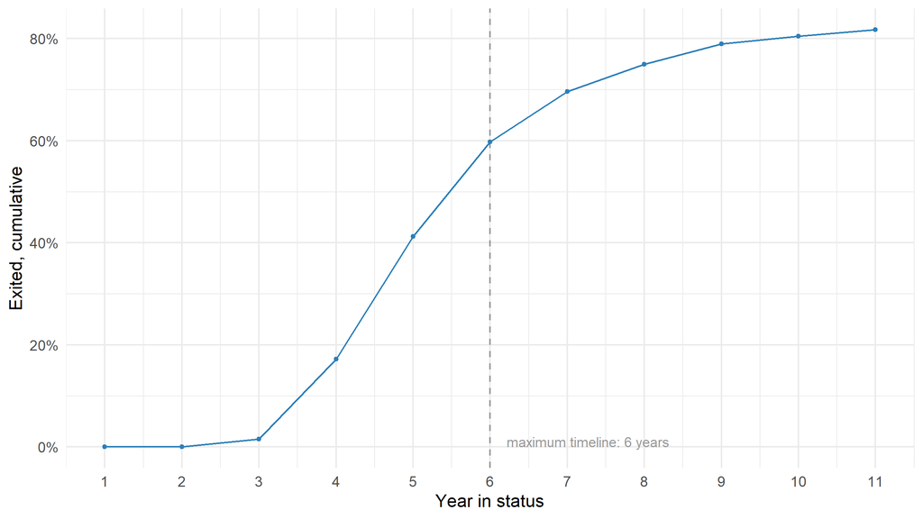

Cumulative exit rate for the selected cohort, by exit year. Censored students are not exiters, so the line is a lower bound. The dashed line marks the maximum timeline.

```r
plot_exit_curve(res$exit_curve, spec)
```

Its x-axis is the exit year, so the curve at year 6 equals F in row 5. The slot’s columns are `GROUP`, `YEAR_IN_STATUS`, `N_AT_ENTRY`, `N_EXITED_CUM`, `CUM_EXIT_RATE` and `SUPPRESSED`.

**The overlay in the stage report**

The stage report draws this figure with `plot_exit_curve(res$exit_curve, spec, survival_est = res$survival_est)`, which adds the at-risk estimate (next section) as a grey line and band. In the current version that overlay is placed by life-table row, while the observed line is placed by exit year. The grey line therefore sits one year to the left of where it belongs. On the simulated data, where the two agree exactly, this shows as a one-year gap between them. Until it is fixed, read the estimate from the table in the next section, not from the figure.

The second slot splits the curve by **initial ELP band**: the band of the student’s first annual Overall Composite score. The package derives the band from the scores, not from a delivered `INITIAL_ELP` column. Students with no annual score, such as alternate-form takers, form their own group.

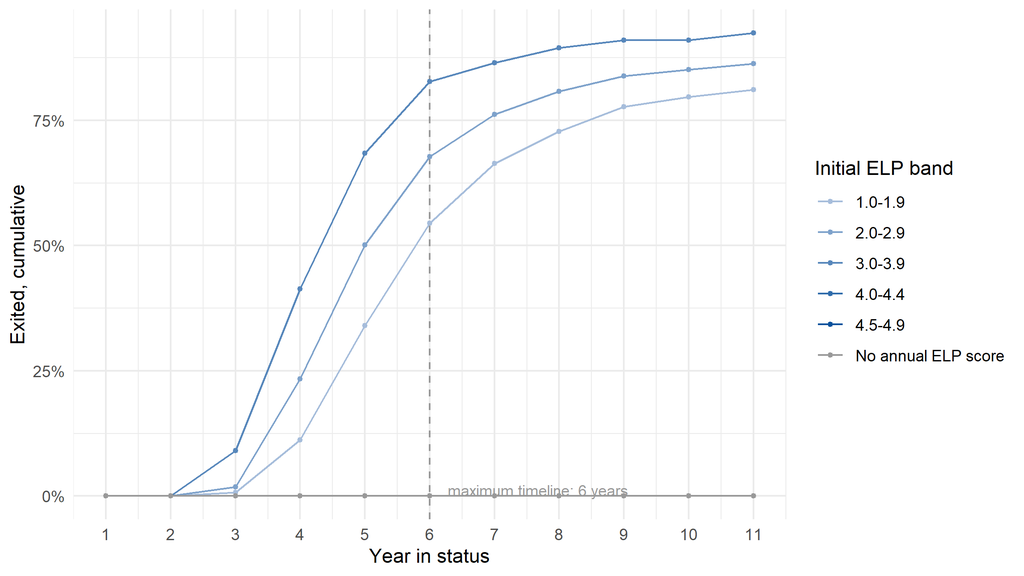

Cumulative exit rate by initial ELP band. Bands below the minimum cell size are suppressed and not drawn.

```r
plot_exit_curve(res$exit_curve_by_initial_band, spec)
```

The last year of the split shows how many students start in each band:

```r
subset(res$exit_curve_by_initial_band,
       YEAR_IN_STATUS == max(YEAR_IN_STATUS),
       c(GROUP, N_AT_ENTRY, N_EXITED_CUM, CUM_EXIT_RATE, SUPPRESSED))
```

```
# A tibble: 6 × 5
  GROUP               N_AT_ENTRY N_EXITED_CUM CUM_EXIT_RATE SUPPRESSED
  <chr>                    <int>        <int>         <dbl> <lgl>
1 1.0-1.9                   1317         1068         0.811 FALSE
2 2.0-2.9                    860          742         0.863 FALSE
3 3.0-3.9                    133          123         0.925 FALSE
4 4.0-4.4                     NA           NA        NA     TRUE
5 4.5-4.9                     NA           NA        NA     TRUE
6 No annual ELP score         55            0         0     FALSE
```

Bands near the exit threshold hold very few kindergarten entrants, because a student who screened at the threshold would not have been identified as an EL. Their suppression is the design working, not a gap in the data.

The “No annual ELP score” group shows no exits. In the simulated data that is by construction: exit requires the annual form, so alternate-form students never exit. It is a limit of the simulation, not a finding.

### The survival estimate: `$survival_est`

Column F counts exits out of everyone who started. The standard discrete-time estimate asks what share *would* have exited had nobody been lost. It compounds each year’s at-risk rate: one minus the product of (1 − D).

```r
ft_check1_survival(res)
```

| Year in status | At risk at year's start | Exit rate that year (D) | Exited, against the starting cohort (F) | Exited, at-risk estimate | 95% CI on the estimate |
| --- | --- | --- | --- | --- | --- |
| Y1 | 2,373 | 0.00 | 0.00 | 0.00 | 0.00–0.00 |
| Y2 | 2,373 | 0.02 | 0.02 | 0.02 | 0.01–0.02 |
| Y3 | 2,336 | 0.16 | 0.17 | 0.17 | 0.16–0.19 |
| Y4 | 1,965 | 0.29 | 0.41 | 0.41 | 0.39–0.43 |
| Y5 | 1,395 | 0.32 | 0.60 | 0.60 | 0.58–0.62 |
| Y6 | 955 | 0.25 | 0.70 | 0.70 | 0.68–0.71 |
| Y7 | 721 | 0.18 | 0.75 | 0.75 | 0.73–0.77 |
| Y8 | 593 | 0.16 | 0.79 | 0.79 | 0.77–0.81 |
| Y9 | 499 | 0.07 | 0.80 | 0.80 | 0.79–0.82 |
| Y10 | 463 | 0.07 | 0.82 | 0.82 | 0.80–0.83 |
| Y11 | 432 | 0.00 | — | 0.82 | 0.80–0.83 |

The columns are `A`, `HAZARD` (column D), `SURVIVING`, `CUM_EXIT_EST`, `SE`, `CI_LO`, `CI_HI` and `CUM_EXIT_OBS` (column F). Rows are life-table rows, not exit years: row 5’s values count exits dated year 6, like F in row 5.

**Only the estimate gets a confidence interval**, from Greenwood’s variance on the complementary log-log scale, which keeps the bounds between 0 and 1. Column F is a count, not an estimate, so it gets none. The interval covers sampling variability in this cohort’s exit rates, not whether the cohort stands for any other.

The simulated cohort has 0 students in column C before the last row, so the estimate and F agree exactly. On real data they will separate, and the gap is the cost of censoring.

### Median years to exit: `$years_to_50`

```r
res$years_to_50
```

```
# A tibble: 2 × 3
  BASIS                                            YEARS_TO_50 REACHED
  <chr>                                                  <int> <lgl>
1 Observed exits, against the cohort as it started           6 TRUE
2 At-risk estimate, allowing for censoring                   6 TRUE
```

`YEARS_TO_50` is the first year by which half the cohort has exited, on the observed basis and on the at-risk estimate. `REACHED = FALSE` means half had not exited by the end of the data, which is a finding in itself. The year is an exit year, like the curve’s. Here the estimate passes one half in life-table row 5, so `compute_years_to_50()` reports year 6.

### Where the cohort ended up: `$at_max_timeline`

```r
ft_check1_timeline(res)
```

| Outcome by the window's end | Students | Share of cohort |
| --- | --- | --- |
| Exited within the ESSA timeline (5 years) | 978 | 0.412 |
| Exited within the maximum timeline (6 years) | 1,418 | 0.598 |
| Exited at any point observed | 1,941 | 0.818 |
| Still classified at the window's edge | 432 | 0.182 |
| Disappeared from the data | 0 | 0.000 |

The columns are `OUTCOME`, `NESTED`, `N`, `PCT` and `SUPPRESSED`. The first three rows (italic) are nested: on time is a subset of within the maximum, which is a subset of exited at all. The last three rows (exited, still classified, disappeared) count every student once. Do not add up the whole column. A zero is shown rather than suppressed, since it discloses no one.

In this simulated cohort, 41% exited within the 5-year ESSA timeline and 60% within the 6-year maximum. These figures show the machinery; they reflect the generator’s settings.

### Model 1, fitted: `$model1` and `$model1_baseline`

Model 1’s fitted half writes the life table as a model, so Model 2 has a baseline. The fits use a **person-period** frame, one row per student per year at risk, built on demand and never stored.

**`$model1` is unconditional:** one term per year in status, no covariate. Its fitted hazards *are* column D:

```r
lt <- res$life_table
cf <- res$model1$coefficients
first <- min(lt$YEAR_IN_STATUS[!is.na(lt$B) & lt$B > 0])  # reference year
yrs <- c(first, as.integer(sub("factor(YEAR_IN_STATUS)", "", cf$TERM[-1],
                               fixed = TRUE)))
data.frame(YEAR_IN_STATUS = yrs,
           FITTED_HAZARD = round(plogis(cf$ESTIMATE[1] + c(0, cf$ESTIMATE[-1])), 4),
           D = round(lt$D[yrs], 4))
```

```
  YEAR_IN_STATUS FITTED_HAZARD      D
1              2        0.0156 0.0156
2              3        0.1588 0.1588
3              4        0.2901 0.2901
4              5        0.3154 0.3154
5              6        0.2450 0.2450
6              7        0.1775 0.1775
7              8        0.1585 0.1585
8              9        0.0721 0.0721
9             10        0.0670 0.0670
```

Years with no exits identify no term and are dropped; `res$model1$dropped` counts them.

**`$model1_baseline` adds the student’s entry score:** their *first* annual Overall Composite score, standardized and fixed for their whole run. It asks whether entry proficiency already sets exit timing.

```r
ft_check1_model1(res)
```

| Covariate (standardised) | Ratio | 95% CI, low | 95% CI, high | p |
| --- | --- | --- | --- | --- |
| ELP score at entry | 1.296 | 1.229 | 1.366 | 0.000 |

```r
ft_check1_model1_dropped(res)
```

| Rows not used, and why | Person-years |
| --- | --- |
| No first annual ELP score (the student was never tested) | 605 |
| Year in status with no exits (no baseline term to identify) | 2,695 |

The ratio is per standard deviation of entry score. Strictly, every ratio in these fits is an odds ratio on the discrete-time hazard; the process this package follows calls Model 2’s a hazard ratio. Rows with no first annual score are dropped, never imputed. The covariate is deliberately *not* the current year’s score: the exit rule is applied to that score, so modeling exit on it would restate the rule.

### Model 2: `$model2`

Model 2 adds the student’s content score from the **year before** to the entry-score model. The subject is the spec’s first academic subject unless you call `compute_model2()` with another `subject`.

```r
ft_check1_model2(res)
```

| Covariate (standardised) | Ratio | 95% CI, low | 95% CI, high | p |
| --- | --- | --- | --- | --- |
| ELP score at entry | 1.032 | 0.952 | 1.119 | 0.447 |
| Prior-year ELA score | 1.363 | 1.251 | 1.485 | 0.000 |

```r
ft_check1_model2_dropped(res)
```

| Rows not used, and why | Person-years |
| --- | --- |
| No first annual ELP score (the student was never tested) | 605 |
| No prior-year ELA score: content testing does not reach that grade, or the student was untested | 9,105 |
| No prior-year ELA score because 2020 has no assessment anywhere (every 2021 row) | 666 |
| Year in status with no exits (no baseline term to identify) | 370 |

Read the ratio on prior-year achievement. At 1, it adds nothing and exit timing is driven by ELP as intended. Away from 1 in either direction, something beyond the language test may be shaping who exits. Here it is 1.36 (95% interval 1.25 to 1.48), a value set by the simulation. Exit in the simulated data is a rule applied to the ELP score alone, so this is not skimming; How to read it explains why the ratio can still sit away from 1.

The dropped-rows table separates why a prior-year score is missing. In the simulated spec, content testing starts in grade 3, so a kindergarten cohort has no prior-year score before grade 4. The simulated data also have no 2020 content scores, so every 2021 person-year drops (666 rows here, beyond those already dropped for having no ELP score). Nothing is imputed.

The two fits use different rows, and the package says so:

```r
cat(check1_nested_note(res))
```

The entry-score ratio is 1.30 on its own and 1.03 once prior achievement joins it. The two fits do not use the same rows: Model 2 keeps only the 3,359 rows that carry a prior-year score, against 10,805. Read the movement as a direction, not a measurement.

`res$model2$n_person_periods` and `n_events` count the rows and exits the fit used. `n_students` counts the cohort’s students before any rows are dropped, not the students left in the fit. The stage report’s note under each model quotes `n_students` as “Fitted on … students”. Read that number as the cohort size.

**Standard errors are cluster-robust on the student** (CR1, clustered on `STUDENT_ID`), because each student contributes several rows. Estimates are unchanged; the intervals count students, not rows. `$quasi_separated` flags a fit whose fitted probabilities reach 0 or 1, meaning a covariate decides the outcome almost perfectly and its ratio cannot be read. Here it is FALSE for all three fits.

### The weighting index (experimental): `$retention_share`, `$selection_strength`, `$grade_weights`

**Not an established statistic**

This is a candidate idea, not a validated method. It has not been tested on real data, nothing in the package uses it, and no decision should rest on it. Every row of `$grade_weights` carries `EXPERIMENTAL = TRUE`, and `$selection_strength$experimental` is `TRUE`.

The index sketches how much weight later grade-level findings can carry:

- **Retention share** is column A over the starting cohort, the share still at risk. It is a hard floor: a year with fewer than `min_cell` students at risk gets weight 0.
- **Selection strength** is |ratio − 1| for Model 2’s ratio. Above the floor, the weight is 1 / (1 + selection strength), a placeholder functional form.

```r
ft_check1_grade_weights(res)
```

| Year in status | Retention share (still at risk) | Candidate weight (EXPERIMENTAL) |
| --- | --- | --- |
| Y1 | 1.00 | 0.73 |
| Y2 | 1.00 | 0.73 |
| Y3 | 0.98 | 0.73 |
| Y4 | 0.83 | 0.73 |
| Y5 | 0.59 | 0.73 |
| Y6 | 0.40 | 0.73 |
| Y7 | 0.30 | 0.73 |
| Y8 | 0.25 | 0.73 |
| Y9 | 0.21 | 0.73 |
| Y10 | 0.20 | 0.73 |
| Y11 | 0.18 | 0.73 |

```r
res$selection_strength$value
```

```
[1] 0.3627415
```

Selection strength is one number for the whole cohort, so the constant weight down the column is not a per-grade result.

## How to read it

**Model 1 gives the shape of exit timing** under current policy and practice: typical years to exit, the share exiting within the timelines, and the share still classified many grades later. That sets realistic expectations and gives you plain language for stakeholders. It does not say whether the threshold is set at the right level, and neither does the band split: a cohort that starts higher and exits sooner is what an exit rule produces.

**Model 2 is the formal test for skimming.** A ratio near 1 supports reading Checks 3 and 4 at face value. A ratio away from 1 suggests the exit process, as implemented, responds to academic performance beyond English proficiency. That is a fact about the process, not about students. Model 2 uses only person-years with a prior-year score (grade 4 onward for a kindergarten cohort), so it describes exits in those years.

Keep one limit in view. Model 2 holds the entry score constant, not the score the exit rule is applied to that year (adding that score would restate the rule). Students whose English grew fastest since entry may also have had higher content scores the year before, so a ratio away from 1 can come from that alone. The simulated data show this: exit there depends on the ELP score alone, and content scores are generated to track it, yet the ratio is 1.36. On a real delivery, treat a ratio away from 1 as a signal to explain, alongside Checks 3 and 4, not as proof of skimming on its own.

## Pitfalls

- **No mean or average time in status.** Time in status is censored, so its mean is not defined. Report median years to exit and the share exited within the timelines. A test keeps Check 1 free of means.
- **Censored is not stuck.** A student who disappears, or is still classified at the end of the data, is censored. What happened next is unknown, so do not count them as non-exiters. Report F beside the at-risk estimate.
- **Keep the exit dating.** A student who is an EL for six years and is reclassified in the seventh did *not* exit within a six-year timeline. The package recomputes this from `EL_STATUS` every run; do not substitute a delivered `YEAR_IN_STATUS`.
- **Column D is not a duration.** It is a rate among students still at risk that year.
- **One entry cohort is not every EL.** Later entrants, including newcomers in the upper grades, are not in it and have different trajectories. Do not generalize to them, and never quote these figures as the state’s overall exit rate.
- **Check the cohort first.** It should be large and stable, with no enrollment anomaly such as a pandemic-era dip.
- **Never use the current year’s ELP score as a covariate.** If you extend the models, keep every covariate fixed at entry or lagged. A current-year score restates the exit rule and leaves the skimming test unable to detect skimming. A package test guards this.
- **Keep the cluster-robust intervals.** Default `glm()` standard errors treat each person-year as independent, so they count rows rather than students.
- **Do not impute missing lags.** Rows without a prior-year score drop from Model 2, with the reason recorded.
- **Do not lower `min_cell` or pool cohorts** to make a suppressed cell appear. Suppressed cells are `NA`, never dropped rows.
- **Simulated ratios are not findings.** Every hazard ratio from the simulated data is a generator setting. On a real delivery, the same model is a genuine test.

## Decide before moving on

Decide **how much weight later grade-level findings can carry**, from Model 1 and Model 2 together:

- **Is the cohort large and stable enough?** Use the candidate cohorts table and column A. If not, say so before relying on the curve.
- **Where is the cohort thin?** Column A, or `$retention_share`, shows where later-grade evidence rests on few students.
- **Is exit shaped by achievement?** If Model 2’s ratio sits away from 1, later-grade comparisons in Checks 3 and 4 may be made on a selected group.

A grade can fail on either count: thin but unselected, or well populated but heavily selected. Record your judgment in words, not as the experimental index’s weights. Check 2 then splits the same cohort into on-time and prolonged exiters.

## Additional checks for multi-criterion exit rules

Check 1 has one Type-gated check, for **Type 3** rules: an overall composite plus another, non-ELP source. Look at the spec’s declared types:

```r
spec_exit_types(spec)
```

```
[1] 1
```

```r
spec_has_type(spec, 3)
```

```
[1] FALSE
```

```r
el_exit_typology()
```

```
                               1                                2
"Single overall composite score"           "Composite-plus-floor"
                               3                                4
   "Composite-plus-other-source"       "Compensatory combination"
                               5                                6
          "Tiered/discretionary"                 "Domain profile"
```

`$type3_covariate` is filled only when:

1. the spec declares Type 3 in `policy$exit$types`;
2. an exit pathway has a term with `from = "academic"`, whose `component` names a content subject (the first such term is used); and
3. the academic table carries that subject.

Model 2 is then refit with that subject’s same-year score as an extra covariate, to ask whether the non-ELP criterion predicts exit timing independent of ELP. The slot holds `criterion_subject`, the refit `model` and a `caption`. The caption warns that if the criterion is an achievement measure in the exit rule, agreement with it in Checks 3 and 4 is partly circular.

The simulated spec is Type 1, so the slot is empty:

```r
is.null(res$type3_covariate)
```

```
[1] TRUE
```

## Render the stage report

`render_step()` renders the Check 1 report to Word and HTML in `reports/`, then scans the output for student identifiers and stops if any appear.

```r
render_step("check1")                     # Word and HTML
render_step("check1", formats = "html")   # HTML only
```

The example report on the simulated data is on the project site.

By default the report runs on the simulated data. For your own delivery, save your results outside the folder you share, render from them, and run the disclosure scan against your own bundle. Give the spec as a full path: the report renders in a temporary folder, where a relative path does not resolve.

```r
dir.create("results", showWarnings = FALSE)
saveRDS(res, "results/check1_results.rds")

files <- render_step("check1",
                     spec_file        = normalizePath("specs/XX_EL_Spec.R"),
                     results_file     = "results/check1_results.rds",
                     check_disclosure = FALSE)
check_output_disclosure(files, bundle)
```

One known issue: the report’s closing line says “Simulated data” whatever the source. Correct or remove it before sharing a report built from a real delivery.

Guide home | Previous: Prep 3: Program implementation | Next: Check 2: On-time vs. prolonged exiters